# Ngrams Project

Hippies

# Introduction

N-gram is a concept from computational linguistics and probability, and it is defined as a contiguous sequence of n items from a sample of text (called corpora). This sequence can be any combination of phonemes, syllables, letters, words since it has a meaning in the language where it comes from. If it is a single word, it is called unigram, an expression with two words is a bigram, and so on (source: https://en.wikipedia.org/wiki/N-gram).

In this work, we retrieved our data from Google Ngram Viewer for the word “peace” from the corpora in English. The English corpora are composed of printed books in this language and their data is aggregated in years, from 1500 to 2019. The program is an online search engine that searches for a given ngram and returns the normalized percentage of appearance of the searched ngrams on books published each year (source: https://en.wikipedia.org/wiki/Google_Ngram_Viewer).

It can be accessed on this page: https://books.google.com/ngrams.

# Setting, libraries, and reading data

> **Data is *Google NGRAMS*.**

> **Obs: 5% of significance for tests**

```r
require(ngramr)
require(fitdistrplus)
require(logspline)
require(tseries)
require(forecast)
require(stringr)
require(PerformanceAnalytics)
require(nortest)
require(strucchange)
```

The series is discontinuous before 1533.

```r
df =
  ngram(
    "peace", year_start = 1533,
    smoothing = 0, count = TRUE, case_ins = TRUE, aggregate = TRUE
  )
```

```r
str(df)
```

```
## Classes 'ngram' and 'data.frame':    487 obs. of  5 variables:
##  $ Year     : int  1533 1534 1535 1536 1537 1538 1539 1540 1541 1542 ...
##  $ Corpus   : Factor w/ 1 level "eng_2019": 1 1 1 1 1 1 1 1 1 1 ...
##  $ Phrase   : Factor w/ 1 level "peace (All)": 1 1 1 1 1 1 1 1 1 1 ...
##  $ Frequency: num  3.06e-05 4.02e-05 3.16e-06 0.00 3.93e-05 ...
##  $ Count    : num  6 1 1 0 4 86 32 1 0 0 ...
##  - attr(*, "case_sensitive")= logi FALSE
##  - attr(*, "smoothing")= num 0
```

```r
summary(df)
```

```
##       Year           Corpus            Phrase      Frequency
##  Min.   :1533   eng_2019:487   peace (All):487   Min.   :0.000e+00
##  1st Qu.:1654                                    1st Qu.:9.903e-05
##  Median :1776                                    Median :1.875e-04
##  Mean   :1776                                    Mean   :2.046e-04
##  3rd Qu.:1898                                    3rd Qu.:2.711e-04
##  Max.   :2019                                    Max.   :9.291e-04
##      Count
##  Min.   :      0.0
##  1st Qu.:    775.5
##  Median :  14546.0
##  Mean   : 384809.5
##  3rd Qu.: 543020.5
##  Max.   :2715105.0
```

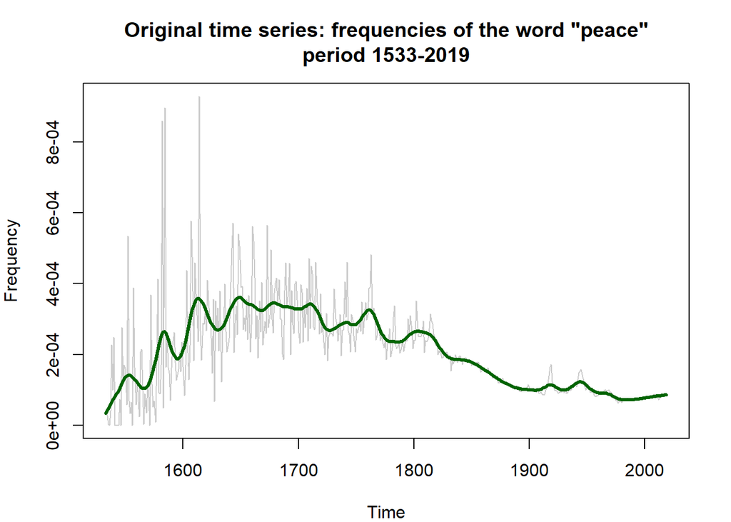

```r
ots =
  ts(
    df[["Frequency"]],
    start=min(df[["Year"]]),
    end=max(df[["Year"]]),
    frequency=1
  )

par(mar=c(4,4,4,2))  # margins: bottom, left, top, right
plot(
  ots, col=rgb(0,0,0,0.2),
  main='Original time series: frequencies of the word "peace"\nperiod 1533-2019',
  xlab="Time", ylab="Frequency"
)
lines(
  predict(
    smooth.spline(ots~time(ots), spar=0.45)
  ),
  lwd=3, col="darkgreen"
)
```

The first half of the series has a different behavior from the second half.

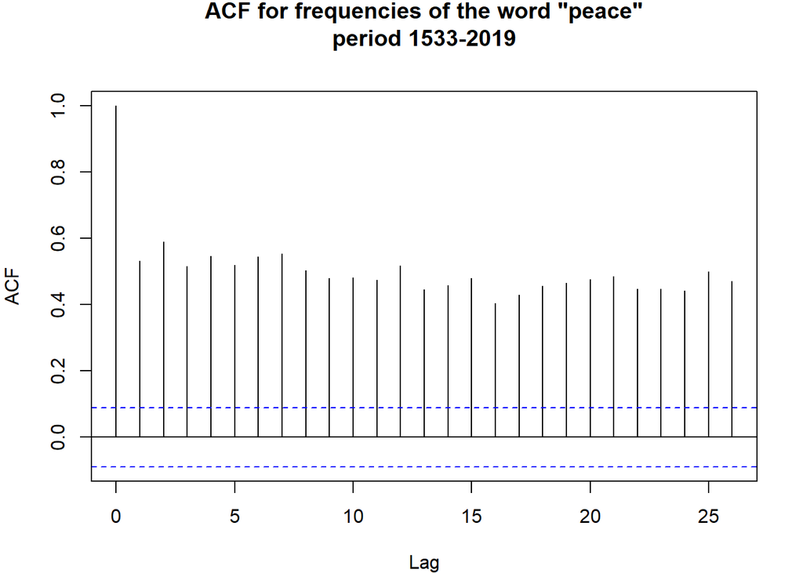

```r
par(mar=c(4,4,4,2))  # margins: bottom, left, top, right
acf(ots, main='ACF for frequencies of the word "peace"\nperiod 1533-2019')
```

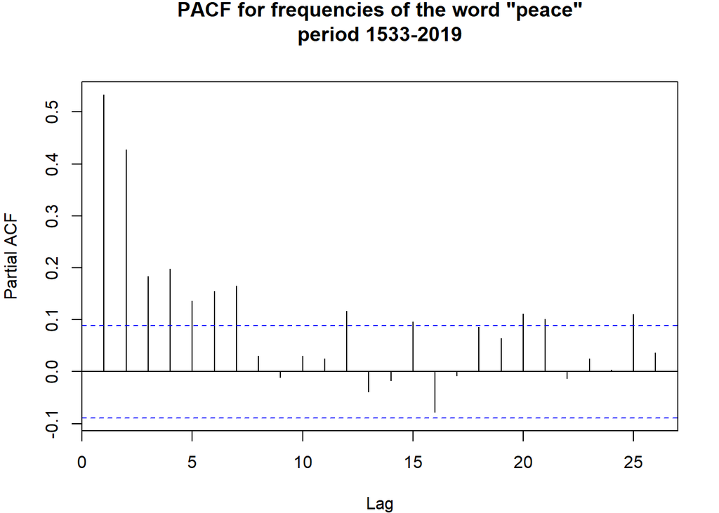

```r
pacf(ots, main='PACF for frequencies of the word "peace"\nperiod 1533-2019')
```

```r
adf.test(ots)
```

```
##
##  Augmented Dickey-Fuller Test
##
## data:  ots
## Dickey-Fuller = -3.2849, Lag order = 7, p-value = 0.07334
## alternative hypothesis: stationary
```

It is non-stationary at 5% but not at 10%.

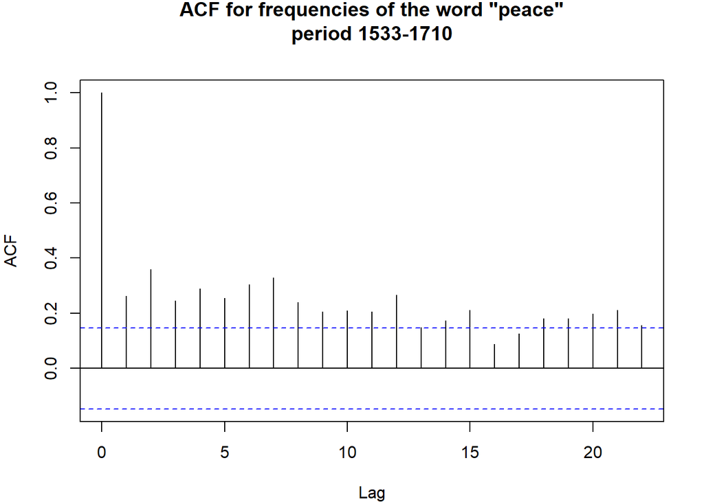

```r
par(mar=c(4,4,4,2))  # margins: bottom, left, top, right
acf(window(ots, end=1710), main='ACF for frequencies of the word "peace"\nperiod 1533-1710')
```

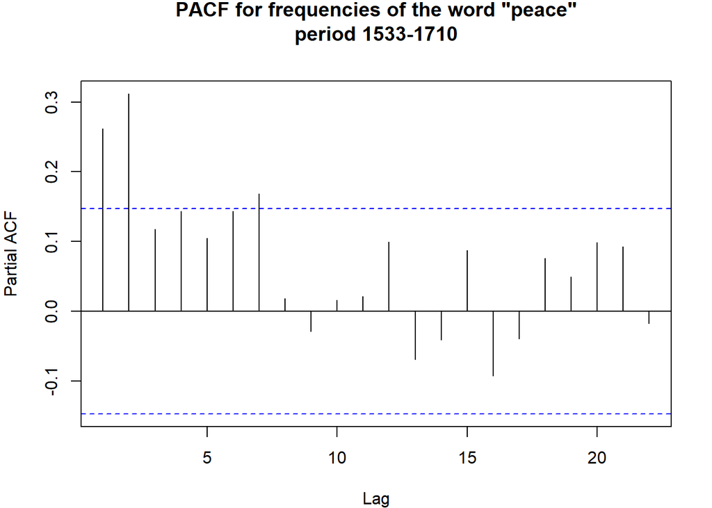

```r
pacf(window(ots, end=1710), main='PACF for frequencies of the word "peace"\nperiod 1533-1710')
```

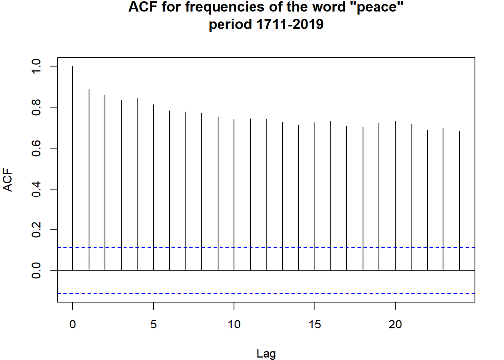

```r
acf(window(ots, start=1711), main='ACF for frequencies of the word "peace"\nperiod 1711-2019')
```

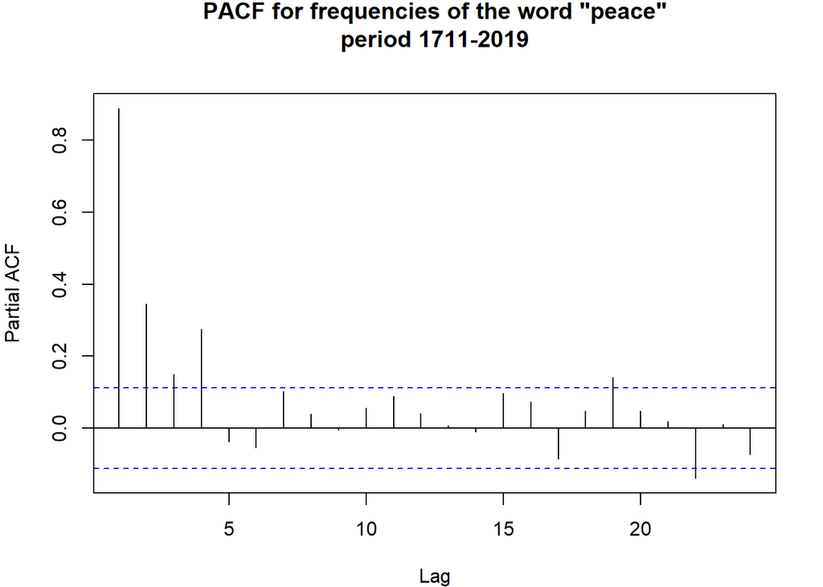

```r
pacf(window(ots, start=1711), main='PACF for frequencies of the word "peace"\nperiod 1711-2019')
```

```r
adf.test(window(ots, end=1710))
```

```
##
##  Augmented Dickey-Fuller Test
##
## data:  window(ots, end = 1710)
## Dickey-Fuller = -4.2123, Lag order = 5, p-value = 0.01
## alternative hypothesis: stationary
```

```r
adf.test(window(ots, start=1711))
```

```
##
##  Augmented Dickey-Fuller Test
##
## data:  window(ots, start = 1711)
## Dickey-Fuller = -3.898, Lag order = 6, p-value = 0.01448
## alternative hypothesis: stationary
```

When we break it, each part is stationary.

```r
complete_ts=ots
ots=window(complete_ts, end=2019-10)  # 2010 to 2019 is for forecast
```

# Structural breaks

Reference: https://cran.r-project.org/web/packages/strucchange/vignettes/strucchange-intro.pdf

```r
fit =
  auto.arima(
    ots,
    seasonal=FALSE,
    test="adf",
    ic="bic",  # I changed to BIC bcs it penalizes model complexity more than AIC and AICc
    lambda=NULL,
    stepwise=FALSE,
    approximation=FALSE,
    max.p=3, max.q=3
  )
summary(fit)
```

```
## Series: ots
## ARIMA(3,0,0) with non-zero mean
##
## Coefficients:
##          ar1     ar2     ar3   mean
##       0.2217  0.3723  0.1886  2e-04
## s.e.  0.0449  0.0428  0.0450  1e-04
##
## sigma^2 estimated as 9.595e-09:  log likelihood=3727.94
## AIC=-7445.89   AICc=-7445.76   BIC=-7425.05
##
## Training set error measures:
##                       ME         RMSE          MAE  MPE MAPE      MASE
## Training set 8.24818e-07 9.754265e-05 5.839932e-05 -Inf  Inf 0.9185002
##                     ACF1
## Training set -0.04057325
```

```r
as.data.frame(round(confint(fit), 4))
```

|  | 2.5 % | 97.5 % |
| --- | --- | --- |
| ar1 | 0.1338 | 0.3096 |
| ar2 | 0.2884 | 0.4561 |
| ar3 | 0.1004 | 0.2769 |
| intercept | 0.0001 | 0.0003 |

We don’t have a theoretical model, as it is shown in the reference (the authors use a theoretical macroeconomic relation), so we assume the following hypothesis: a time series with a structural change fitted by only one model (set of parameters) has residuals which show that the model is not suitable. This inadequacy can be detected by testing structural breaks of the **level** of the residuals.

The next test can detect many structural breaks.

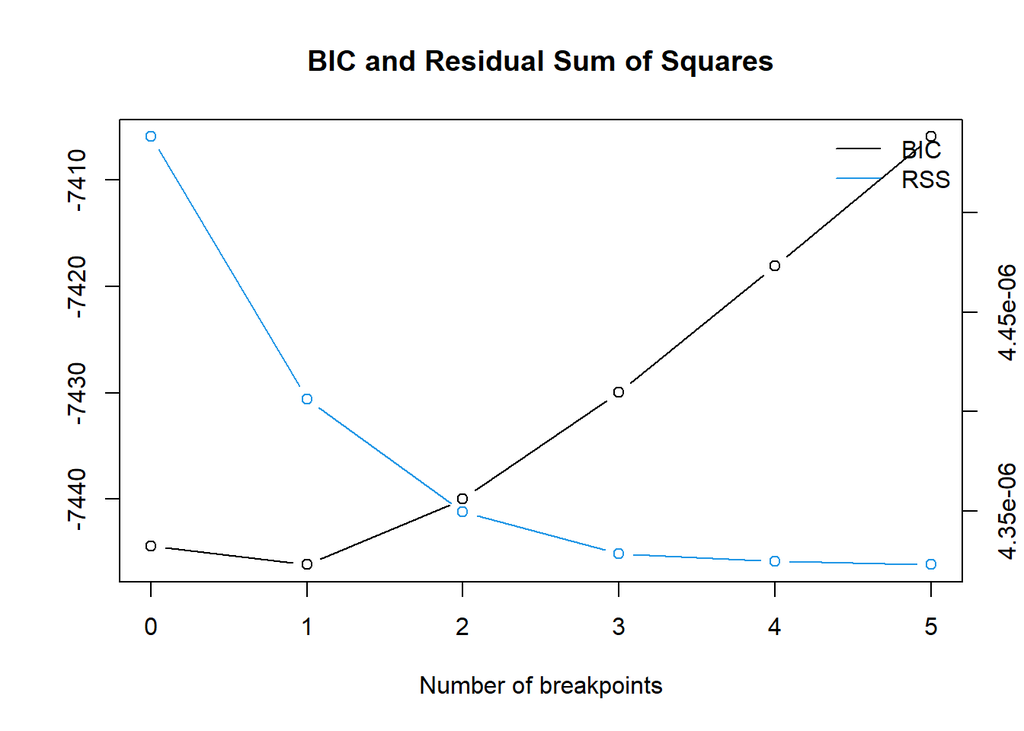

```r
# Bai & Perron (2003) test - H0: no structural change
BPtest=breakpoints(residuals(fit)~1, breaks=5)
plot(BPtest, breaks = 5)
```

Minimum BIC is at 1. So we have 1 structural break.

```r
breakdates(BPtest)
```

```
## [1] 1816
```

```r
#round(min(time(ots)) + breakdates(BPtest)*(max(time(ots)) - min(time(ots))))  # use it when it is a fraction
```

The structural break happens at 1816.

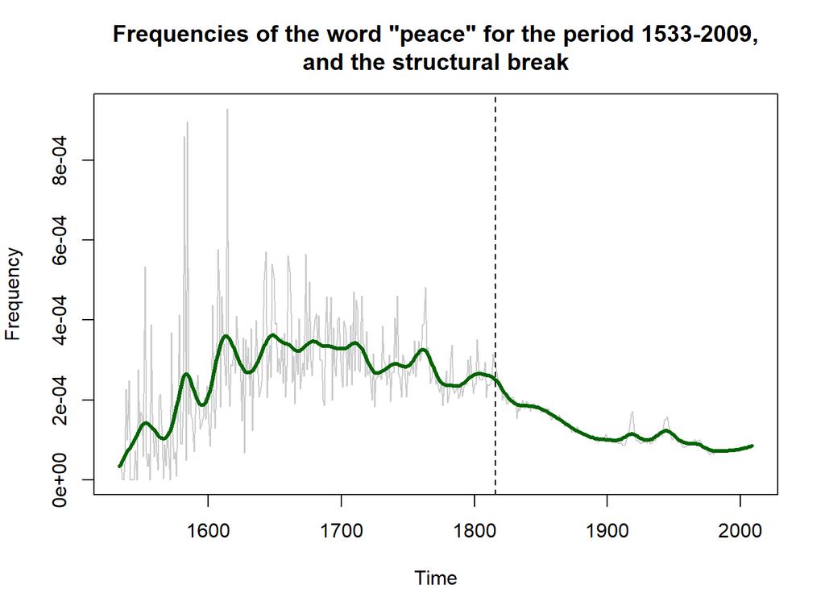

```r
par(mar=c(4,4,4,2))  # margins: bottom, left, top, right
plot(
  ots, col=rgb(0,0,0,0.2),
  main='Frequencies of the word "peace" for the period 1533-2009,\nand the structural break',
  xlab="Time", ylab="Frequency"
)
lines(
  predict(
    smooth.spline(ots~time(ots), spar=0.45)
  ),
  lwd=3, col="darkgreen"
)
abline(v=1816, lty="dashed")
```

Vertical line at the structural break.

# One structural break (hidden states Markov model)

Reference: https://rpubs.com/simaan84/regime_switching

The basic idea of this model is to presume that the time series evolves according to two (or more) regimes determined by a Markov chain with two states that we can’t observe.

However, the log-likelihood can be decomposed using the law of total probability in a way that take into account the effect of the Markov chain on the time series.

The main idea is that the distribution of the value of the time series at a time T is independent of its past values once it is known the state for the Markov chain at the time T.

The final log-likelihood is a recursion which depends of the parameters for each state and the transition probability matrix for the Markov chain.

```r
require(MSwM)

res=residuals(fit)
fit0=lm(res ~ 1)

best=msmFit(fit0, k=2, sw=rep(TRUE, 2))  # sw=(TRUE, TRUE) means two intercepts and two res. standard dev/err
```

Note that the transition matrix shows that the structural change is unidirectional. In addition, res.std. errors are different.

```r
summary(best)
```

```
## Markov Switching Model
##
## Call: msmFit(object = fit0, k = 2, sw = rep(TRUE, 2))
##
##         AIC       BIC   logLik
##   -8071.176 -8050.506 4037.588
##
## Coefficients:
##
## Regime 1
## ---------
##                Estimate Std. Error t value Pr(>|t|)
## (Intercept)(S)        0          0     NaN      NaN
##
## Residual standard error: 0.0001241562
## Multiple R-squared: 1.862e-34
##
## Standardized Residuals:
##           Min            Q1           Med            Q3           Max
## -3.236263e-04 -2.972336e-05 -2.123662e-09  1.577876e-08  7.132940e-04
##
## Regime 2
## ---------
##                Estimate Std. Error t value Pr(>|t|)
## (Intercept)(S)        0          0     NaN      NaN
##
## Residual standard error: 1.291911e-05
## Multiple R-squared:     0
##
## Standardized Residuals:
##           Min            Q1           Med            Q3           Max
## -4.058816e-05 -3.088634e-08  1.035054e-52  3.832571e-09  4.150263e-05
##
## Transition probabilities:
##              Regime 1    Regime 2
## Regime 1 9.999973e-01 0.005176215
## Regime 2 2.735406e-06 0.994823785
```

Next, we show that this (hidden states Markov) model of regime-switching finds a structural change at a date similar to the date we formerly found, which corresponds to 284 in the following plot (the plot shows probabilities for each regime).

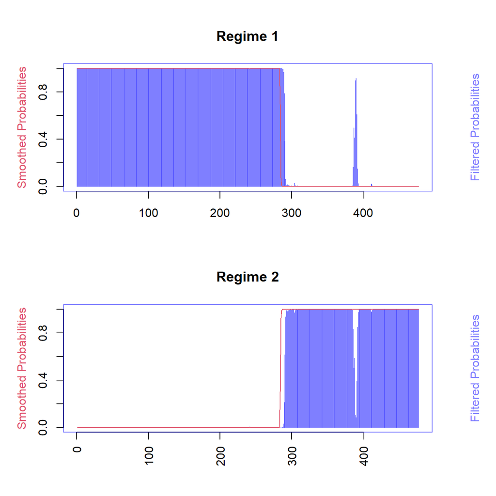

```r
par(mar=c(4,4,4,2), col=rgb(0,0,1,0.5))  # margins: bottom, left, top, right

plotProb(best, 1)
```

Why did these structural breaks happen?

Shifts in the relative frequency of the word “peace” might be related to changes in legislation, technological improvements, social development, and historical events:

1. Change in legislation: at the end of the XVIII century, changes in legislation (the USA and GB) made it easier to publish dissent texts (source: https://www.britannica.com/topic/publishing/Spread-of-education-and-literacy#ref28633).
2. Technological improvements: several innovations related to publishing happened at the beginning of the XIX century and made it much cheaper (source: https://www.britannica.com/topic/publishing/Spread-of-education-and-literacy#ref28633).
3. Social development: increase in population size during the XIX century (2x in GB, 5x in the USA) and higher social status associated with reading (source: https://www.britannica.com/topic/publishing/Spread-of-education-and-literacy#ref28633).
4. Historical events: several major events in American and British history, associated with peace and war, happened around 1816:
   1. War against Great Britain in 1812 (source: https://history.state.gov/milestones/1801-1829/war-of-1812), part of the world scenario of the Napoleonic Wars.
   2. War and against the Barbary States (pirate states in North Africa) in 1816 (source: https://history.state.gov/milestones/1801-1829/barbary-wars).
   3. The Rush-Bagot Pact, 1817 and Convention of 1818, between the USA and Great Britain, about patrolling the border with Canada (source: https://history.state.gov/milestones/1801-1829/rush-bagot).
   4. Acquisition of Florida: Treaty of Adams-Onis (1819) and Transcontinental Treaty (1821), a series of border conflicts between Spain and the USA, fueled by the support of Great Britain to the Spanish colonies (source: https://history.state.gov/milestones/1801-1829/florida).

# 2 different models

## First model - 1533-1816

```r
ots1=window(ots, end=1816)
```

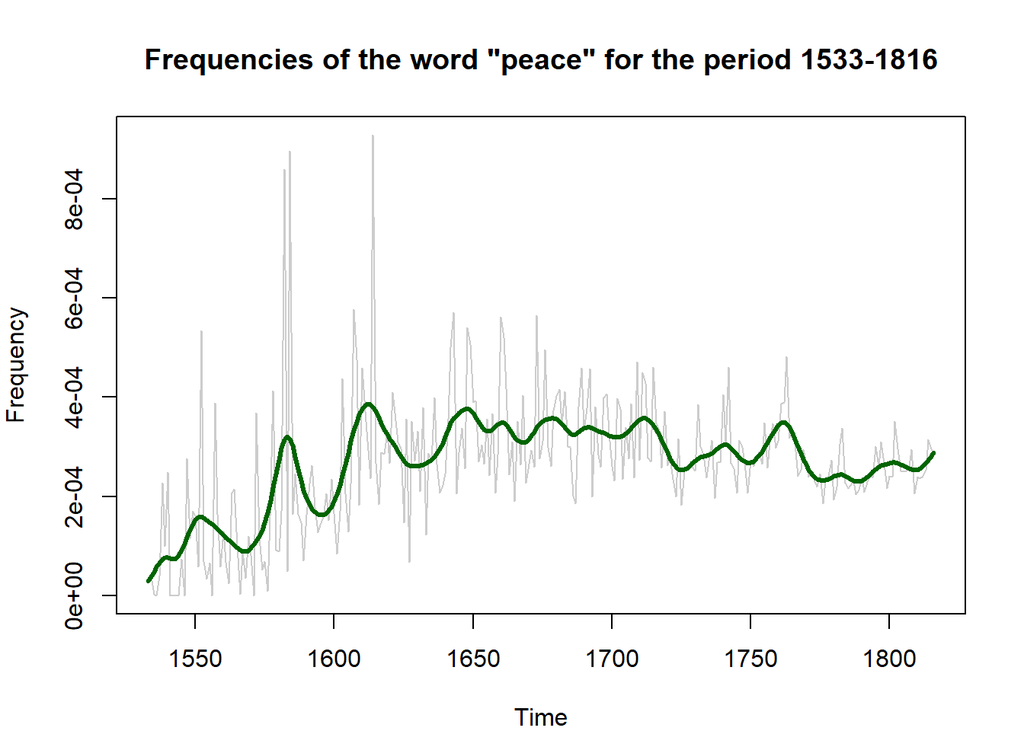

```r
par(mar=c(4,4,4,2))  # margins: bottom, left, top, right
plot(
  ots1, col=rgb(0,0,0,0.2),
  main='Frequencies of the word "peace" for the period 1533-1816',
  xlab="Time", ylab="Frequency"
)
lines(
  predict(
    smooth.spline(ots1~time(ots1), spar=0.45)
  ),
  lwd=3, col="darkgreen"
)
```

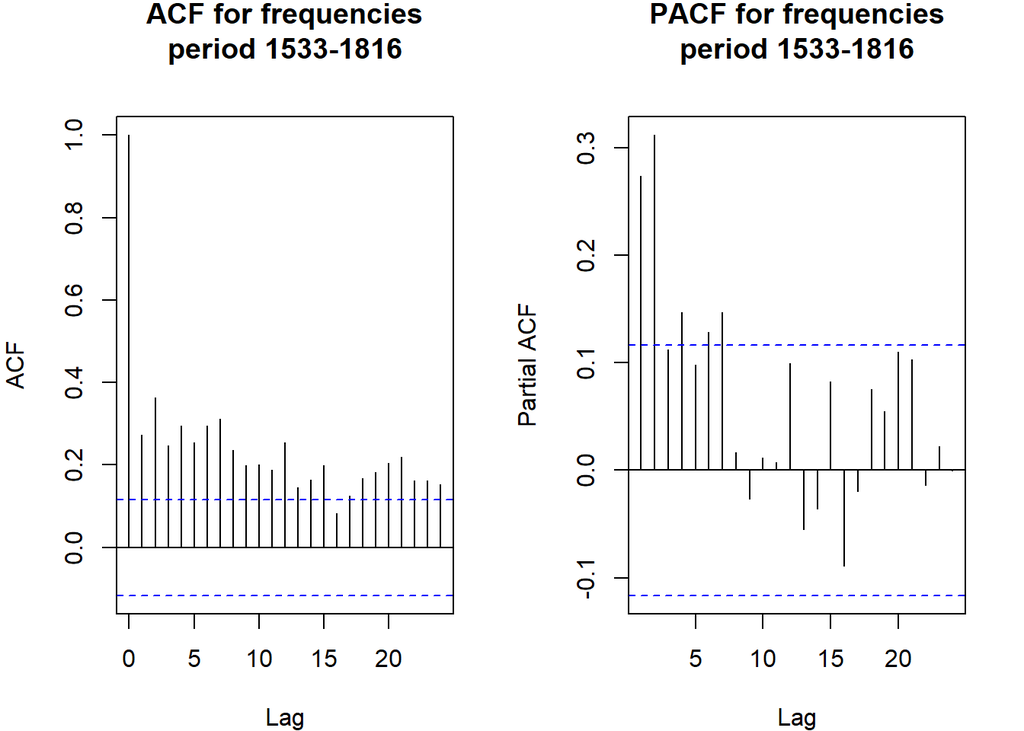

```r
par(mar=c(4,4,4,2), mfrow=c(1,2))  # margins: bottom, left, top, right
acf(ots1, main="ACF for frequencies\nperiod 1533-1816")
pacf(ots1, main="PACF for frequencies\nperiod 1533-1816")
```

```r
adf.test(ots1)
```

```
##
##  Augmented Dickey-Fuller Test
##
## data:  ots1
## Dickey-Fuller = -3.3503, Lag order = 6, p-value = 0.06312
## alternative hypothesis: stationary
```

It is non-stationary at 5% but not at 10%.

```r
fit_1 =
  auto.arima(
    ots1,
    seasonal=FALSE,
    test="adf",
    ic="bic",  # I changed to BIC bcs it penalizes model complexity more than AIC and AICc
    lambda=NULL,
    stepwise=FALSE,
    approximation=FALSE,
    max.p=3, max.q=3
  )
summary(fit_1)
```

```
## Series: ots1
## ARIMA(2,0,1) with non-zero mean
##
## Coefficients:
##          ar1     ar2      ma1   mean
##       0.9257  0.0604  -0.8676  2e-04
## s.e.  0.0864  0.0766   0.0672  1e-04
##
## sigma^2 estimated as 1.421e-08:  log likelihood=2164.32
## AIC=-4318.63   AICc=-4318.42   BIC=-4300.39
##
## Training set error measures:
##                        ME         RMSE          MAE  MPE MAPE      MASE
## Training set 7.295323e-06 0.0001183568 7.737577e-05 -Inf  Inf 0.7556539
##                      ACF1
## Training set -0.002287252
```

```r
as.data.frame(round(confint(fit_1), 4))
```

|  | 2.5 % | 97.5 % |
| --- | --- | --- |
| ar1 | 0.7563 | 1.0951 |
| ar2 | -0.0897 | 0.2104 |
| ma1 | -0.9992 | -0.7359 |
| intercept | 0.0000 | 0.0004 |

> Checking the residuals

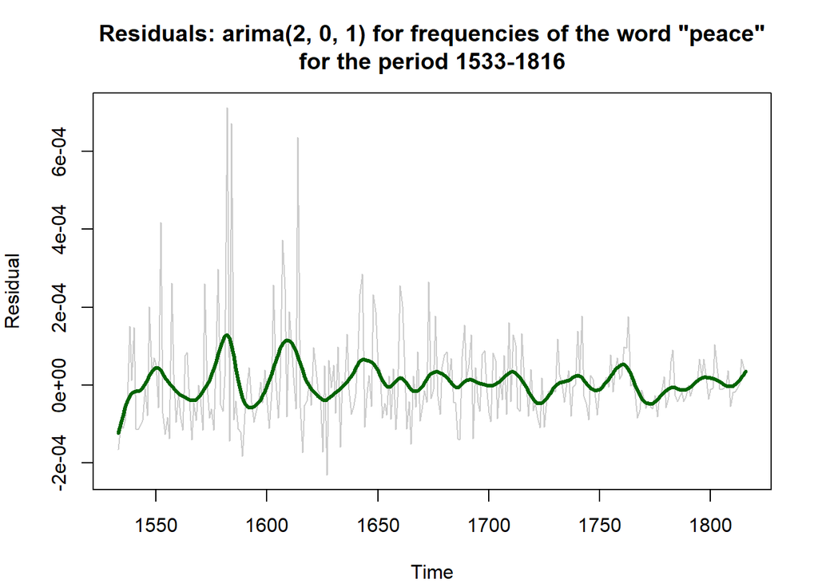

```r
resid=residuals(fit_1)

par(mar=c(4,4,4,2))  # margins: bottom, left, top, right
plot(
  resid, col=rgb(0,0,0,0.2),
  main='Residuals: arima(2, 0, 1) for frequencies of the word "peace"
for the period 1533-1816',
  xlab="Time", ylab="Residual"
)
lines(
  predict(
    smooth.spline(resid~time(resid), spar=0.45)
  ),
  lwd=3, col="darkgreen"
)
```

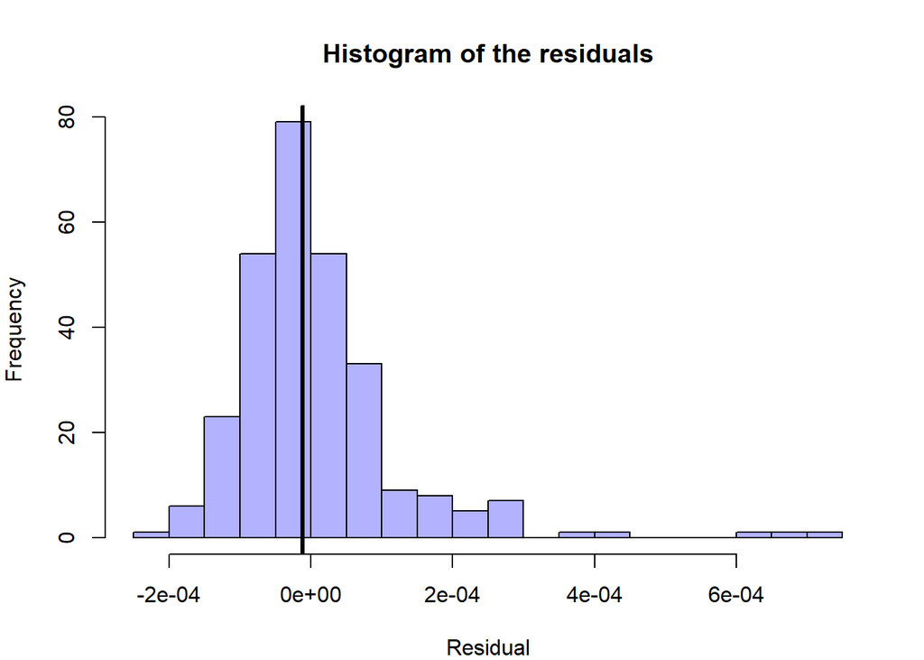

```r
par(mar=c(4,4,4,2))  # margins: bottom, left, top, right
hist(resid, breaks=15, main="Histogram of the residuals", xlab="Residual", col=rgb(0,0,1,0.3)); abline(v=median(resid), lwd=3)
```

```r
shapiro.test(resid)
```

```
##
##  Shapiro-Wilk normality test
##
## data:  resid
## W = 0.82044, p-value < 2.2e-16
```

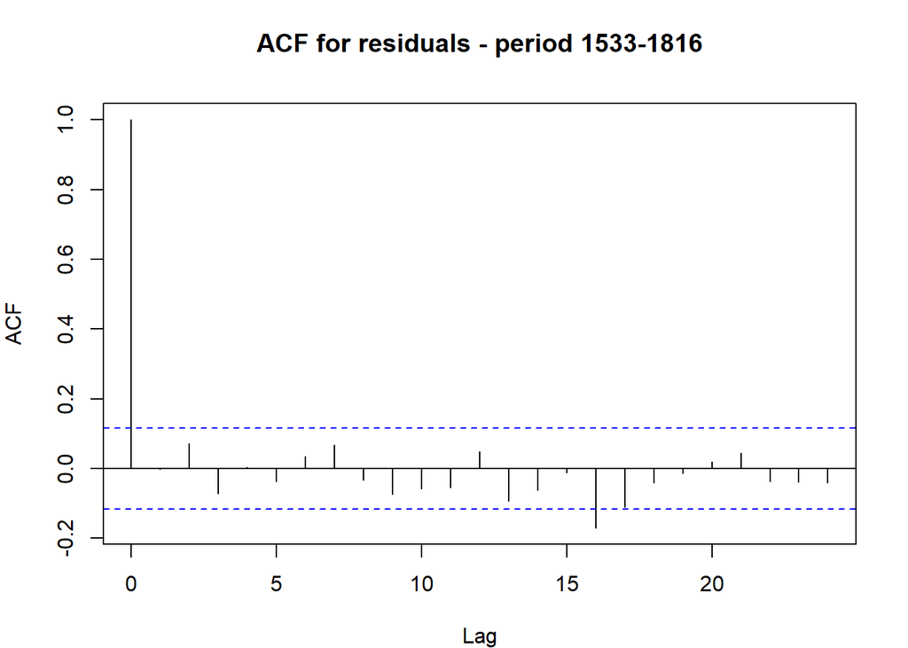

```r
par(mar=c(4,4,4,2))  # margins: bottom, left, top, right
acf(resid, main="ACF for residuals - period 1533-1816")
```

```r
Box.test(resid, type = "Ljung-Box")  # H0: indep./uncorr.
```

```
##
##  Box-Ljung test
##
## data:  resid
## X-squared = 0.0015015, df = 1, p-value = 0.9691
```

Residuals are independent/uncorrelated.

> Checking the squared residuals

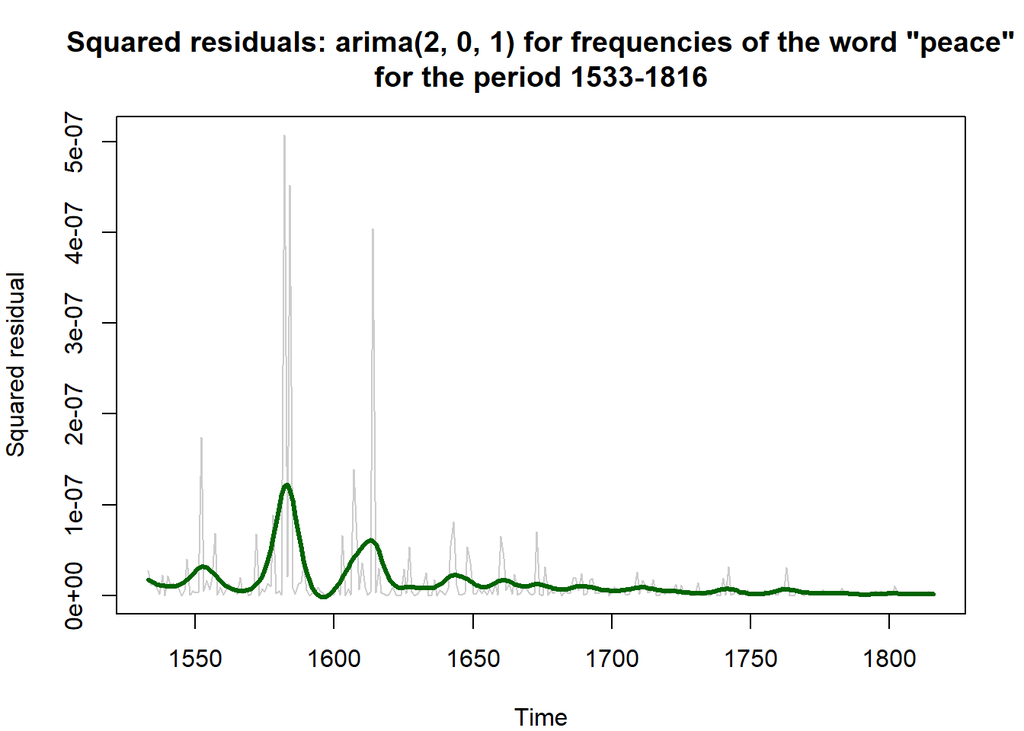

```r
par(mar=c(4,4,4,2))  # margins: bottom, left, top, right
plot(
  abs(resid)^2, col=rgb(0,0,0,0.2),
  main='Squared residuals: arima(2, 0, 1) for frequencies of the word "peace"
for the period 1533-1816',
  xlab="Time", ylab="Squared residual"
)
lines(
  predict(
    smooth.spline(abs(resid)^2~time(abs(resid)^2), spar=0.45)
  ),
  lwd=3, col="darkgreen"
)
```

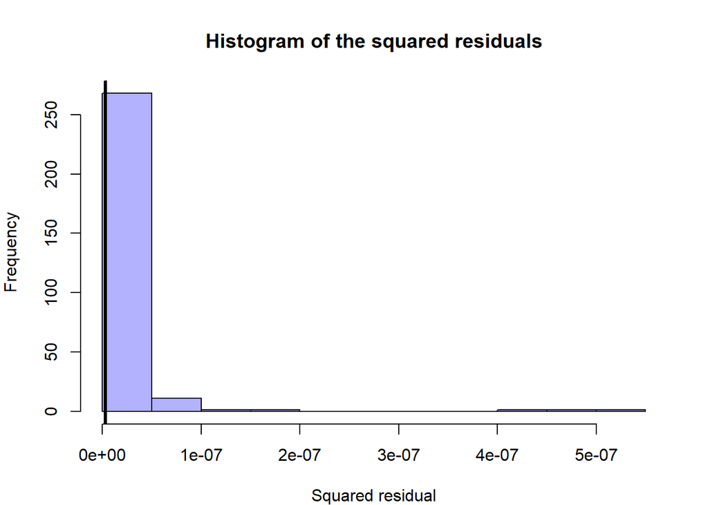

```r
par(mar=c(4,4,4,2))  # margins: bottom, left, top, right
hist(abs(resid)^2, breaks=15, main="Histogram of the squared residuals",
     xlab="Squared residual", col=rgb(0,0,1,0.3)); abline(v=median(abs(resid)^2), lwd=3)
```

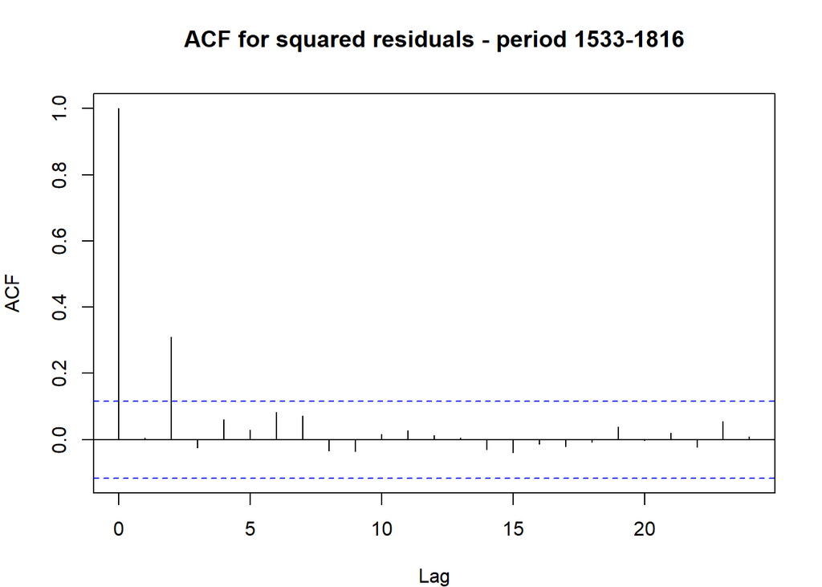

```r
par(mar=c(4,4,4,2))  # margins: bottom, left, top, right
acf(abs(resid)^2, main="ACF for squared residuals - period 1533-1816")
```

```r
Box.test(abs(resid)^2, type = "Ljung-Box")  # H0: indep./uncorr.
```

```
##
##  Box-Ljung test
##
## data:  abs(resid)^2
## X-squared = 0.010222, df = 1, p-value = 0.9195
```

## Second model - 1817-2009

```r
ots2=window(ots, start=1817)
```

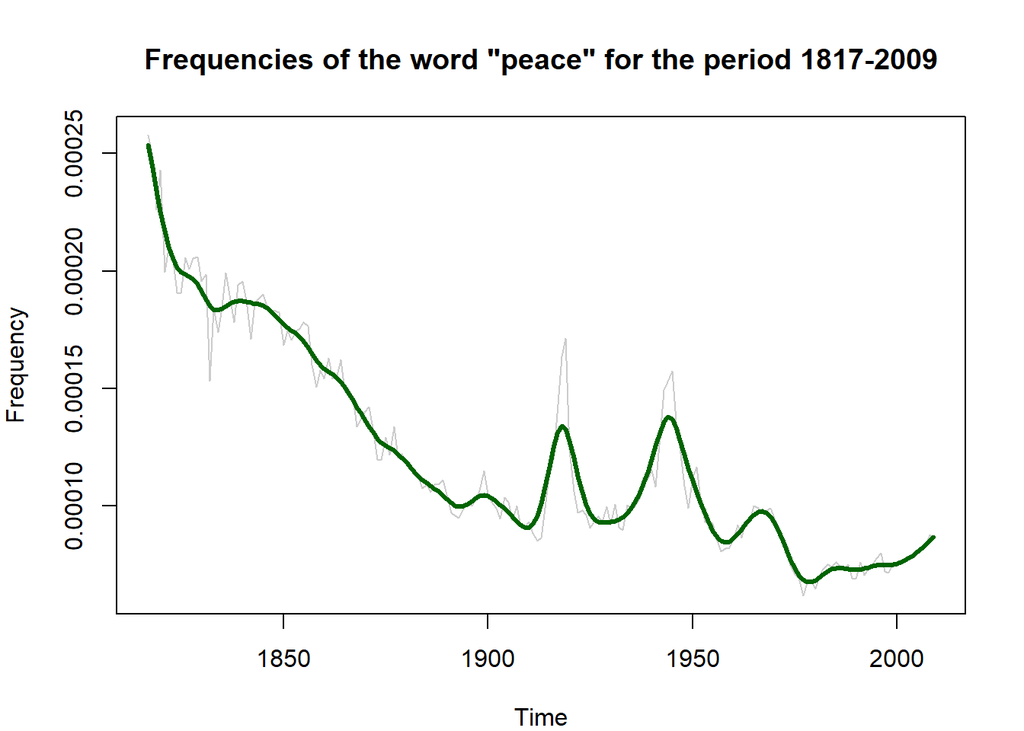

```r
par(mar=c(4,4,4,2))  # margins: bottom, left, top, right
plot(
  ots2, col=rgb(0,0,0,0.2),
  main='Frequencies of the word "peace" for the period 1817-2009',
  xlab="Time", ylab="Frequency"
)
lines(
  predict(
    smooth.spline(ots2~time(ots2), spar=0.45)
  ),
  lwd=3, col="darkgreen"
)
```

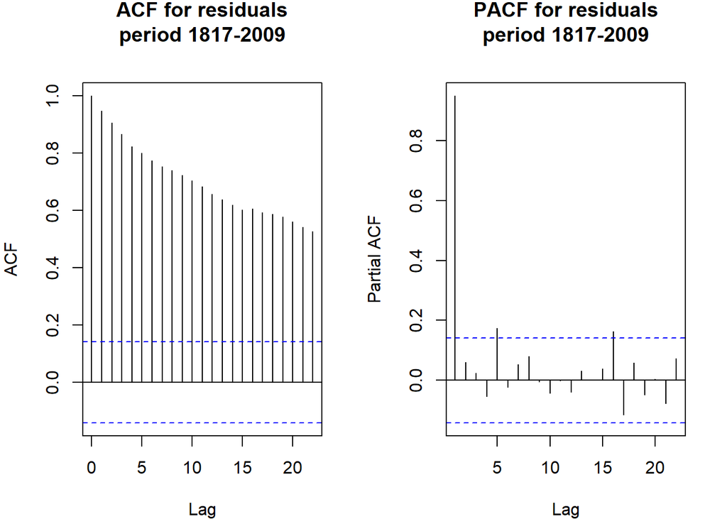

```r
par(mar=c(4,4,4,2), mfrow=c(1,2))  # margins: bottom, left, top, right
acf(ots2, main="ACF for residuals\nperiod 1817-2009")
pacf(ots2, main="PACF for residuals\nperiod 1817-2009")
```

```r
adf.test(ots2)
```

```
##
##  Augmented Dickey-Fuller Test
##
## data:  ots2
## Dickey-Fuller = -2.7838, Lag order = 5, p-value = 0.2481
## alternative hypothesis: stationary
```

ADF test does not reject non-stationarity even at 10%. But the best model for this series with auto.arima is an AR(1). We prefer to differentiate the series.

```r
dots2=na.omit(diff(ots2))
```

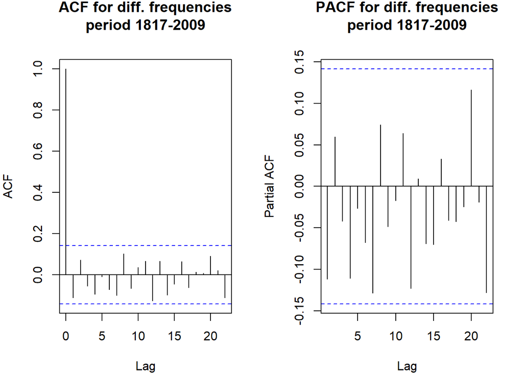

```r
par(mar=c(4,4,4,2), mfrow=c(1,2))  # margins: bottom, left, top, right
acf(dots2, main="ACF for diff. frequencies\nperiod 1817-2009")
pacf(dots2, main="PACF for diff. frequencies\nperiod 1817-2009")
```

```r
fit_2 =
  auto.arima(
    dots2,
    seasonal=FALSE,
    test="adf",
    ic="bic",  # I changed to BIC bcs it penalizes model complexity more than AIC and AICc
    lambda=NULL,
    stepwise=FALSE,
    approximation=FALSE,
    max.p=3, max.q=3
  )
summary(fit_2)
```

```
## Series: dots2
## ARIMA(0,0,0) with zero mean
##
## sigma^2 estimated as 9.689e-11:  log likelihood=1941.08
## AIC=-3880.17   AICc=-3880.15   BIC=-3876.91
##
## Training set error measures:
##                         ME         RMSE          MAE MPE MAPE      MASE
## Training set -8.954279e-07 9.843036e-06 6.549165e-06 100  100 0.6769678
##                    ACF1
## Training set -0.1118436
```

```r
fit_2=Arima(ots2, order=c(0,1,0))
summary(fit_2)
```

```
## Series: ots2
## ARIMA(0,1,0)
##
## sigma^2 estimated as 9.689e-11:  log likelihood=1941.08
## AIC=-3880.17   AICc=-3880.15   BIC=-3876.91
##
## Training set error measures:
##                         ME        RMSE          MAE        MPE    MAPE
## Training set -8.894525e-07 9.81752e-06 6.516567e-06 -0.8246778 5.25744
##                   MASE       ACF1
## Training set 0.9950226 -0.1123449
```

> Checking the residuals

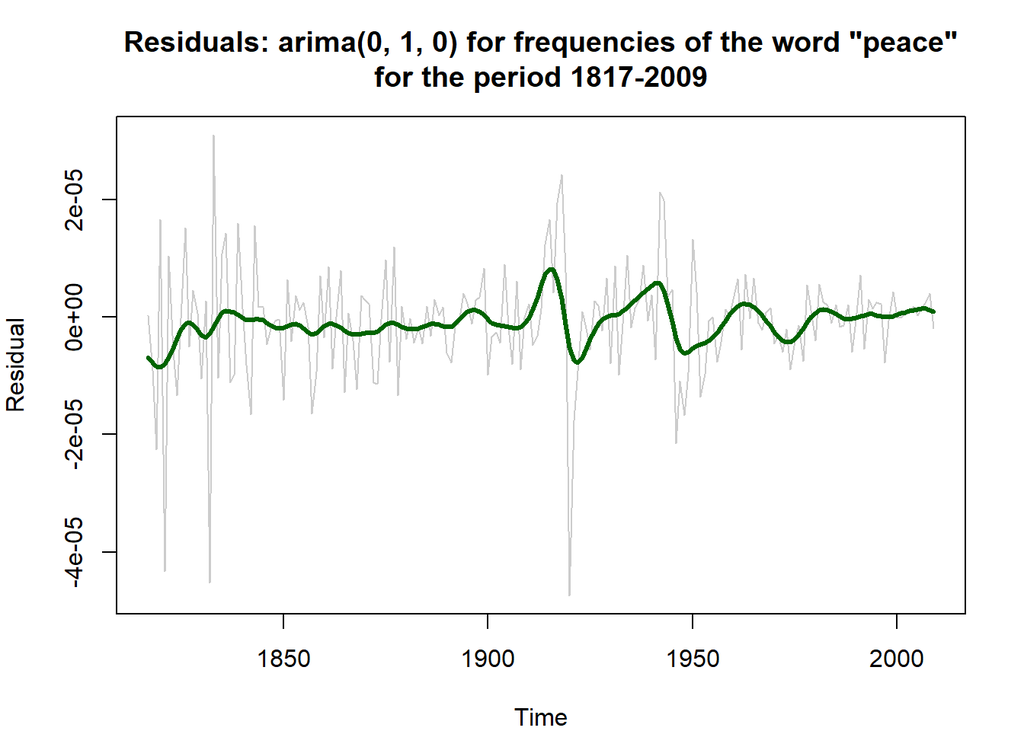

```r
resid=residuals(fit_2)

par(mar=c(4,4,4,2))  # margins: bottom, left, top, right
plot(
  resid, col=rgb(0,0,0,0.2),
  main='Residuals: arima(0, 1, 0) for frequencies of the word "peace"
for the period 1817-2009',
  xlab="Time", ylab="Residual"
)
lines(
  predict(
    smooth.spline(resid~time(resid), spar=0.45)
  ),
  lwd=3, col="darkgreen"
)
```

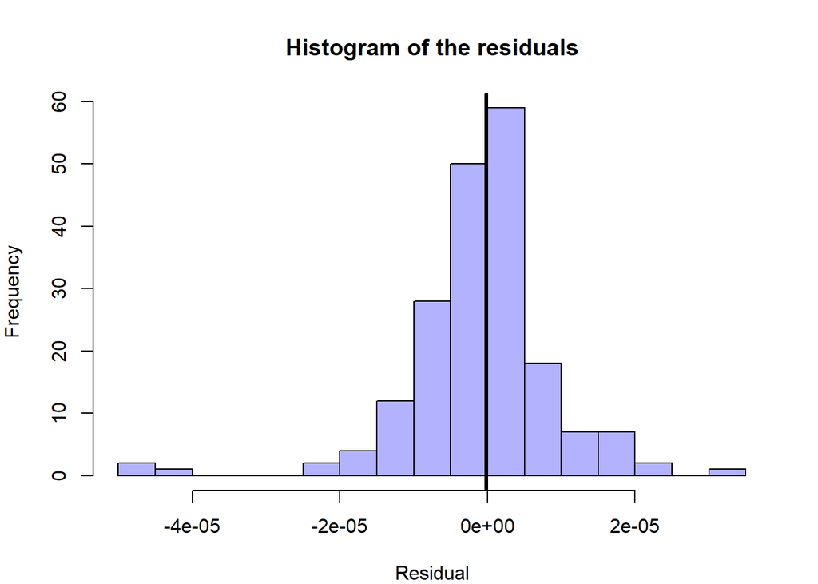

```r
par(mar=c(4,4,4,2))  # margins: bottom, left, top, right
hist(resid, breaks=15, main="Histogram of the residuals", xlab="Residual", col=rgb(0,0,1,0.3)); abline(v=median(resid), lwd=3)
```

```r
shapiro.test(resid)
```

```
##
##  Shapiro-Wilk normality test
##
## data:  resid
## W = 0.89939, p-value = 3.876e-10
```

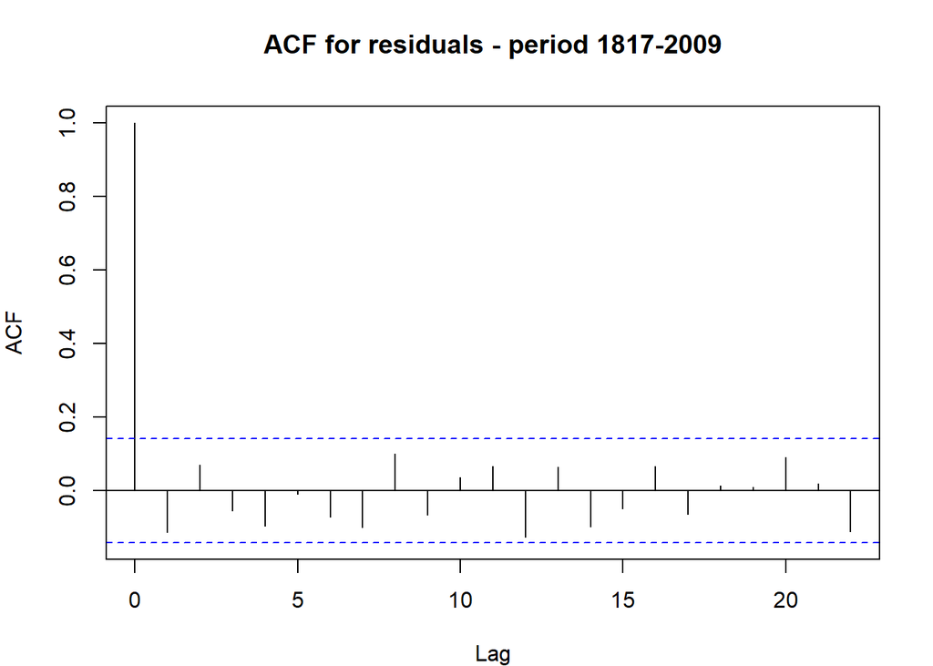

```r
par(mar=c(4,4,4,2))  # margins: bottom, left, top, right
acf(resid, main="ACF for residuals - period 1817-2009")
```

```r
Box.test(resid, type = "Ljung-Box")  # H0: indep./uncorr.
```

```
##
##  Box-Ljung test
##
## data:  resid
## X-squared = 2.474, df = 1, p-value = 0.1157
```

Residuals are independent/uncorrelated.